# Aula 10 - Introdução à Ciência dos Dados

Seu Nome

2023-06-01

## Setup

```r
knitr::opts_chunk$set(echo = TRUE, message = FALSE, warning = FALSE)
options(scipen = 9999, digits = 2)

# Pacotes utilizados
library(tidyverse) # readr::read_csv2()
library(ggthemes)  # theme_minimal()
library(lmtest)
library(DescTools)
library(car)
library(stargazer) # stargazer(): tabelas formatadas
library(knitr)     # kable(): tabelas formatadas
```

## Artigo:

Boente et. al. (2006) analisaram diversos métodos para a estimação de custos, e abordaram a utilização de modelos de regressão, vamos tentar reproduzir os principais resultados envolvendo modelos de regressão com os dados exibidos no artigo.

## Importação e Preparação dos dados para análise.

A variável `Mês/Ano` precisa ser importada mas não é utilizada na modelagem.

```r
dados_custos <- read_csv2("dados/custos.csv",
                          locale = locale("pt"),
                          skip = 1,
                          col_names = c("mes", "unidades_vendidas", "custo_total"),
                          col_types = cols(mes = col_date(format = "%b/%y"),
                                           unidades_vendidas = col_double(),
                                           custo_total = col_double()))
glimpse(dados_custos)
```

```
## Rows: 15
## Columns: 3
## $ mes               <date> 2005-01-01, 2005-02-01, 2005-03-01, 2005-04-01, 200…
## $ unidades_vendidas <dbl> 23074, 72282, 70762, 76601, 79637, 56143, 70040, 568…
## $ custo_total       <dbl> 532324, 1648914, 1680112, 1765484, 1834827, 1365052,…
```

```r
dados_custos <- dplyr::select(dados_custos, -mes)
glimpse(dados_custos)
```

```
## Rows: 15
## Columns: 2
## $ unidades_vendidas <dbl> 23074, 72282, 70762, 76601, 79637, 56143, 70040, 568…
## $ custo_total       <dbl> 532324, 1648914, 1680112, 1765484, 1834827, 1365052,…
```

## Análise Exploratória dos Dados

### Gráfico de Dispersão

Vamos fazer um gráfico de dispersão entre o custo total e as unidades vendidas, além disso, vamos inserir uma reta estimada de regressão linear.

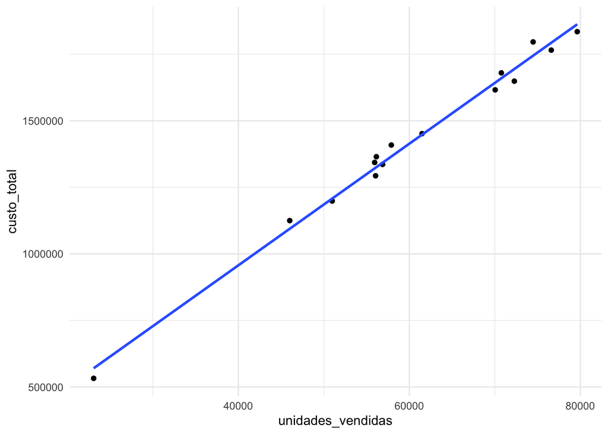

```r
ggplot(dados_custos, aes(x = unidades_vendidas, y = custo_total)) +
  geom_point() +
  geom_smooth(method = lm, se = FALSE) +
  theme_minimal()
```

Vamos melhorar os limites exibidos nos eixos x e y, é sempre importante incluir a origem em gráfico. Podemos obter limites adequados, observando os valores máximos das variáveis:

```r
summary(dados_custos)
```

```
##  unidades_vendidas  custo_total
##  Min.   :23074     Min.   : 532324
##  1st Qu.:55998     1st Qu.:1314796
##  Median :57892     Median :1408882
##  Mean   :60550     Mean   :1426432
##  3rd Qu.:71522     3rd Qu.:1664513
##  Max.   :79637     Max.   :1834827
```

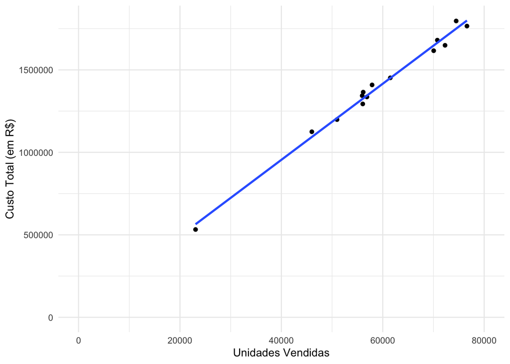

```r
ggplot(dados_custos, aes(x = unidades_vendidas, y = custo_total)) +
  geom_point() +
  geom_smooth(method = lm, se = FALSE) +
  xlim(0,80000) +
  ylim(0,1800000) +
  labs(x = "Unidades Vendidas",
       y = "Custo Total (em R$)") +
  theme_minimal()
```

Observando o gráfico de dispersão, o modelo de regressão linear utilizados pelos autores parece adequado? O gráfico indica a presença de outliers problemáticos?

O gráfico de dispersão indica que um modelo linear parece adequado para modelar a relação entre as Unidades Vendidas e o Custo Total de produção.

O gráfico indica uma forte correlação linear positiva entre as variáveis e não indica a presença de outliers que podem distorcer a relação entre as variáveis.

Tabela de estatísticas descritivas das variáveis em análise.

### Estatísticas Descritivas

```r
kable(psych::describe(dados_custos))
```

|  | vars | n | mean | sd | median | trimmed | mad | min | max | range | skew | kurtosis | se |
| --- | --- | --- | --- | --- | --- | --- | --- | --- | --- | --- | --- | --- | --- |
| unidades_vendidas | 1 | 15 | 60550 | 14486 | 57892 | 61965 | 17618 | 23074 | 79637 | 56563 | -0.87 | 0.48 | 3740 |
| custo_total | 2 | 15 | 1426432 | 332536 | 1408882 | 1463794 | 311787 | 532324 | 1834827 | 1302504 | -1.03 | 0.92 | 85860 |

## Estimação do Modelo de Regressão Linear Simples

Um modelo de regressão é estimado com a função `lm` (de *linear model*) e os resultados da estimação podem ser vistos usando a função `summary`

```r
modelo <- lm(custo_total ~ unidades_vendidas, data = dados_custos)
summary(modelo)
```

```
##
## Call:
## lm(formula = custo_total ~ unidades_vendidas, data = dados_custos)
##
## Residuals:
##    Min     1Q Median     3Q    Max
## -45549 -27659  -6295  26516  51730
##
## Coefficients:
##                    Estimate Std. Error t value          Pr(>|t|)
## (Intercept)       43099.506  38645.415    1.12              0.28
## unidades_vendidas    22.846      0.622   36.74 0.000000000000016 ***
## ---
## Signif. codes:  0 '***' 0.001 '**' 0.01 '*' 0.05 '.' 0.1 ' ' 1
##
## Residual standard error: 33700 on 13 degrees of freedom
## Multiple R-squared:  0.99,   Adjusted R-squared:  0.99
## F-statistic: 1.35e+03 on 1 and 13 DF,  p-value: 0.000000000000016
```

## Diagnóstico do Modelo

1. Teste RESET de Especificação

```r
## Teste de linearidade
lmtest::resettest(modelo, type = "regressor")
```

```
##
##  RESET test
##
## data:  modelo
## RESET = 1, df1 = 2, df2 = 11, p-value = 0.3
```

O teste RESET (valor-p = 0.3, $\alpha$ = 5%) forneceu evidências de que um modelo linear é uma especificação adequada.

2. Teste Jarque-Bera de normalidade.

```r
## Teste de Normalidade de Jarque-Bera
DescTools::JarqueBeraTest(modelo$residuals, robust = TRUE)
```

```
##
##  Robust Jarque Bera Test
##
## data:  modelo$residuals
## X-squared = 0.9, df = 2, p-value = 0.6
```

O Teste de normalidade de Jarque-Bera (valor-p = 0.6, $\alpha$ = 5%) forneceu evidências de que a hipótese nula de que os resíduos do modelo seguem uma distribuição aproximadamente normal não deve ser rejeitada.

3. Teste Breustch-Pagan de Heterocedasticidade.

```r
## Teste de Breusch-Pagan: homocedasticidade
lmtest::bptest(modelo)
```

```
##
##  studentized Breusch-Pagan test
##
## data:  modelo
## BP = 0.1, df = 1, p-value = 0.8
```

O Teste de homogeneidade de variâncias de Breusch-Pagam (valor-p = 0.8, $\alpha$ = 5%) forneceu evidências de que a hipótese nula de que a variância dos resíduos é homogênea não deve ser rejeitada.

4. Teste de Durbin-Watson

```r
# Teste de Durbin-Watson
car::durbinWatsonTest(modelo)
```

```
##  lag Autocorrelation D-W Statistic p-value
##    1           0.074           1.7    0.51
##  Alternative hypothesis: rho != 0
```

O Teste de autocorrelação dos resíduos de Durbin-Watson (valor-p = 0.5, $\alpha$ = 5%) forneceu evidências de que a hipótese nula de que os resíduos não são autocorrelacionados não deve ser rejeitada.

## Questões

**O modelo estimado parece adequado? Explique.**

**Resp.:**

Sendo $x$, o número de unidades vendidas, podemos escrever o modelo de regressão linear estimado como:

$$\hat{\text{custos totais}} = 43100,00 + 23,00\times (\text{unidades
vendidas})$$

Além disso, a estimativa do $R^2$-ajustado. igual a 99%, indica que as unidades vendidas possui forte capacidade explicativa do custo total.

**Qual a interpretação das estimativas pontuais ($\hat{\beta}_0$ e $\hat{\beta}_1$) ? Quais as estimatativas por intervalo, como 95% de confiança, de $\beta_o$ e $\beta_1$?**

**Resp.:**

```r
confint(modelo, level = 0.95)
```

```
##                    2.5 % 97.5 %
## (Intercept)       -40389 126588
## unidades_vendidas     22     24
```

**Obtenha previsões pontuais e por IP(95%) do custo total caso as unidades vendidas sejam iguais a 80.000, 85.000 e 90.000, respectivamente.**

**Resp.:**

Podemos utilizar o modelo estimado para fazer previsões dos custos totais para diferentes de níveis de atividade (vendas). A função `predict` produz estimativas dos intervalos de predicão com o nível de confiança desejado:

```r
x <- data.frame(unidades_vendidas = c(80000, 85000, 90000))
predict(modelo, x, interval = "prediction", level = 0.95)
```

```
##       fit     lwr     upr
## 1 1870789 1791176 1950401
## 2 1985019 1902956 2067082
## 3 2099250 2014275 2184225
```

## Comunicação dos Resultados

A função `stargazer`, do pacote `stargazer`, produz código $LaTeX$, código HTML e texto ASCII para criar tabelas bem formatadas que contêm resultados de análise de regressão de vários modelos.

A função também pode gerar tabelas de estatísticas descritivas e para a exibição de dados.

Vamos gerar uma tabela com os resultados básicos do modelo de regressão:

```r
stargazer(modelo,
          covariate.labels = c("Unidades Vendidas", "Intercepto"),
          style = "aer",
          digits = 2,
          dep.var.labels = c("Custos Totais (reais)"),
          ci = TRUE,
          type = "html",
          out = "tabela_html")
```

|  | Custos Totais (reais) |
| --- | --- |
| Unidades Vendidas | 23.00*** |
|  | (22.00, 24.00) |
| Intercepto | 43,100.00 |
|  | (-32,644.00, 118,843.00) |
| Observations | 15 |
| R<sup>2</sup> | 0.99 |
| Adjusted R<sup>2</sup> | 0.99 |
| Residual Std. Error | 33,705.00 (df = 13) |
| F Statistic | 1,350.00*** (df = 1; 13) |
| *Notes:* | ***Significant at the 1 percent level. |
|  | **Significant at the 5 percent level. |
|  | *Significant at the 10 percent level. |

## Referência

BOENTE, Diego Rodrigues; DE MELO, Clayton Levy Lima; TARSO, Paulo de. “Métodos de estimação de custos: Estudo de caso de uma empresa comercial com enfoque na análise de regressão.” *In:* **Anais do Congresso Brasileiro de Custos-ABC**. 2006.